{% raw %}

{% endraw %} {% raw %}

{% endraw %} {% raw %}

```python
%nbdev_default_export splits
```

{% endraw %} {% raw %}

```python
%nbdev_export

import pandas
import os
import numpy
import seaborn
import logging
import matplotlib.pyplot as plt
from importlib import reload
from ehv import core

numpy.random.seed(42)
```

{% endraw %} {% raw %}

```python
%nbdev_export

from sklearn.model_selection import StratifiedKFold, PredefinedSplit
from collections import Counter
import matplotlib.pyplot as plt
from joblib import load, dump
from ehv import load
from functools import partial
```

{% endraw %} {% raw %}

```python
core.load_config("../config_cp0293.yml")
```

{% endraw %} {% raw %}

```python
df_201 = load.remove_unwanted_features(load.load_raw_ideas(core.DATA_EHV201, load_labels=True))
```

{% endraw %} {% raw %}

```python
df_201 = df_201.drop(columns=df_201.filter(regex=".*Intensity_MC(DAPI|TMR|Cy5|MCP).*"))
df_201_meta = df_201[["label", "replicate", "timepoint"]]
df_201 = df_201.drop(columns=["label", "replicate", "timepoint"])
df_201.shape
```

```
(150257, 134)
```

{% endraw %}

# Data stats

{% raw %}

```python
sel = df_201_meta["label"] != "unknown"
```

{% endraw %}

## timepoint

{% raw %}

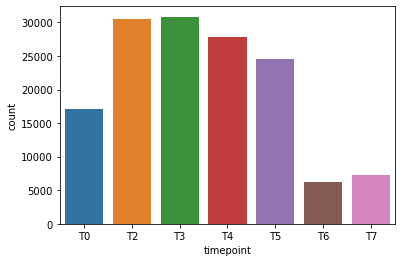

```python
seaborn.countplot("timepoint", data=df_201_meta[sel])
```

{% endraw %} {% raw %}

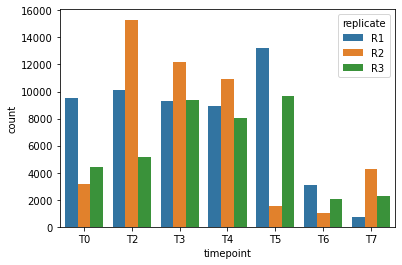

```python
seaborn.countplot("timepoint", hue="replicate", data=df_201_meta[sel])
```

{% endraw %} {% raw %}

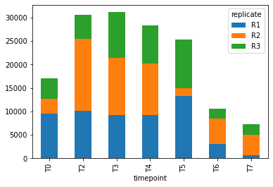

```python
df_201_meta.groupby("timepoint")["replicate"].value_counts().unstack().plot.bar(stacked=True)
```

{% endraw %}

## replicate

{% raw %}

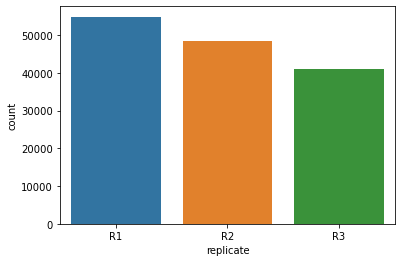

```python
seaborn.countplot("replicate", data=df_201_meta[sel])
```

{% endraw %} {% raw %}

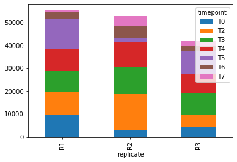

```python
df_201_meta.groupby("replicate")["timepoint"].value_counts().unstack().plot.bar(stacked=True)
```

{% endraw %}

## label

{% raw %}

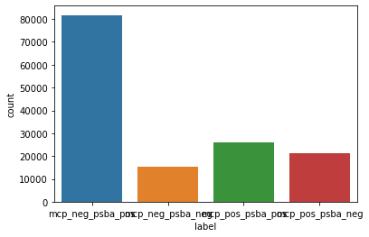

```python
seaborn.countplot("label", data=df_201_meta[sel])
```

{% endraw %} {% raw %}

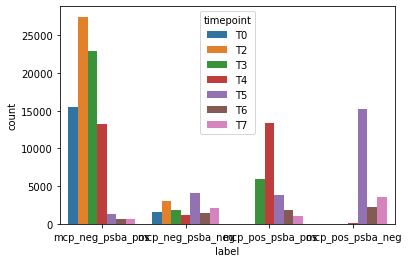

```python
seaborn.countplot("label", hue="timepoint", data=df_201_meta[sel])
```

{% endraw %} {% raw %}

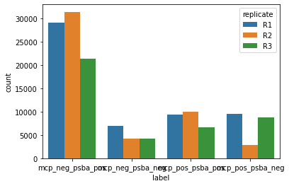

```python
seaborn.countplot("label", hue="replicate", data=df_201_meta[sel])
```

{% endraw %}

# 3-fold replicate splits with nested 3x3-fold stratified splits wrt labels

The cross-validation schema is nested. Each outer fold consists of the first, second or third replicate from each timepoint. The nested folds are 3-fold splits, stratified with respect to the infection stage labels (as acquired through manual gating in IDEAS on TMR and Cy5 intensity). The stratification is done to ensure that each split has enough instances from each infection stage. This is important as the cells differ in morphology from stage to stage. However, we are only interested here in testing whether or not it is possible to predict fluorescence intensity as a proxy for mRNA content from bright-field data. Therefore, we take the stages out of the equation by stratifying the splits.

{% raw %}

```python
outer_fold = numpy.full(shape=(len(df_201),), dtype=int, fill_value=-1)
for i, rep in enumerate(sorted(df_201_meta["replicate"].unique())):
    outer_fold[(df_201_meta["replicate"] == rep).values] = i

inner_folds = [[] for _ in numpy.unique(outer_fold)]
for i, (train_idx, _) in enumerate(PredefinedSplit(outer_fold).split()):
    for _ in range(3):
        splitter = StratifiedKFold(n_splits=3, shuffle=True, random_state=42)
        inner_fold = numpy.full(fill_value=-1, shape=(len(train_idx),), dtype=int)
        for idx, (_, test_idx) in enumerate(splitter.split(numpy.arange(len(train_idx)), df_201_meta["label"].iloc[train_idx])):
            inner_fold[test_idx] = idx
        inner_folds[i].append(inner_fold)
```

{% endraw %}

# Check folds

{% raw %}

```
(0.0, 100.0)
```

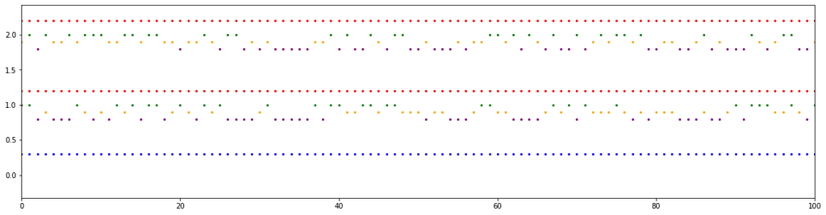

```python
fig, ax = plt.subplots(figsize=(20, 5))
for i, (train_idx, test_idx) in enumerate(PredefinedSplit(outer_fold).split()):
    ax.scatter(train_idx, [i+0.2]*len(train_idx), c="red", s=5)
    ax.scatter(test_idx, [i+0.3]*len(test_idx), c="blue", s=5)

    splitter = PredefinedSplit(inner_folds[i][0])
    for j, ((_, test_idx), c) in enumerate(zip(splitter.split(), ["green", "orange", "purple"])):

        m = list(map(lambda x: train_idx[x], test_idx))

        ax.scatter(m, [i-j/10]*len(test_idx),c=c, s=5)

ax.set_xlim(0, 100)
```

{% endraw %} {% raw %}

```python
dump([outer_fold, inner_folds], core.FOLDS)
```

```
['/home/maximl/Data/Experiment_data/weizmann/EhV/201/outer_replicate_inner_3x3_strat.dat']
```

{% endraw %}

# Preprocess per fold

{% raw %}

```python
%nbdev_export

def standardizer(X, mean, std=1.0):
    return (X-mean)/std
```

{% endraw %} {% raw %}

```python
%nbdev_export

def preprocess_funcs(df, target, outer_fold, inner_folds):

    outer_fold_funcs = []
    inner_fold_funcs = []

    for i, (train_idx, _) in enumerate(PredefinedSplit(outer_fold).split()):

        X = df.iloc[train_idx]
        y = target.iloc[train_idx]

        outer_fold_funcs.append((
            partial(standardizer, mean=X.mean(), std=X.std()),
            partial(standardizer, mean=y.mean())
        ))

        for inner_fold in inner_folds[i]:
            tmp = []
            for nested_train_idx, _ in PredefinedSplit(inner_fold).split():

                X_train = X.iloc[nested_train_idx]
                mean, std = X.mean(), X.std()

                y_mean = y.iloc[nested_train_idx].mean()

                tmp.append((
                    partial(standardizer, mean=mean, std=std),
                    partial(standardizer, mean=y_mean)
                ))

            inner_fold_funcs.append(tmp)

    return outer_fold_funcs, inner_fold_funcs
```

{% endraw %}